# Havets motor

Hvorfor Danmark ikke ligner Labrador

Simon Messell · Middelfart Gymnasium & HF

15. september 2026

## To byer — og København ligger nordligst

Første spørgsmål

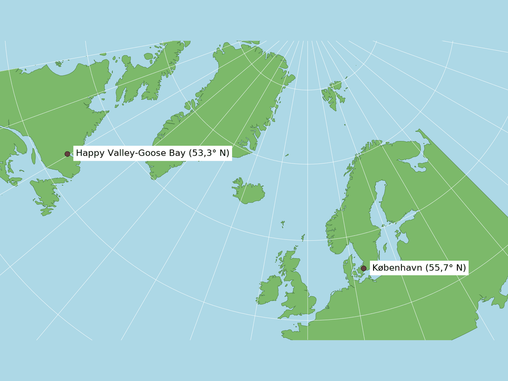

Klimanormaler 1991–2020

**København** 55,7° nord · Danmark +1,4 °C middel i januar · året rundt 9,2 °C

**Happy Valley-Goose Bay** 53,3° nord · Labrador, Canada −17 °C middel i januar · året rundt 0,4 °C

## 18 graders forskel — og kun om vinteren

Gæt — I har ét minut

[figure not shown]

Om sommeren er de to byer næsten ens. Det er **vinteren**, der er mærkelig — og København ligger endda længere mod nord. Så det er ikke afstanden til polen.

## Golfstrømmen henter varme sydfra

Svarets første halvdel

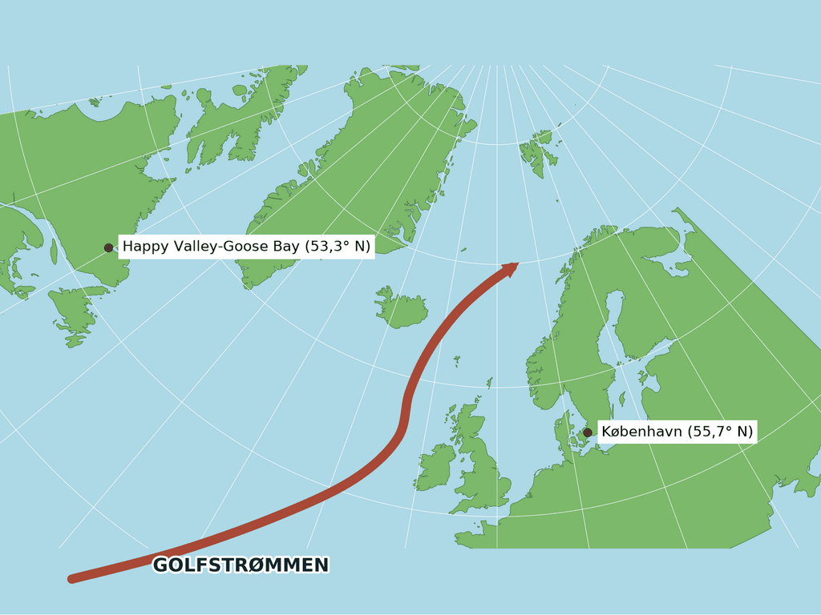

Varmt overfladevand fra Mexicogolfen løber hele vejen op langs Europa og forbi Danmark. Labrador får ingenting. **Men hvor bliver alt det vand så af?**

## Densitet — hvor tungt vandet er

Nøgleordet

[figure not shown]

### Koldt vand er tungere

Det lægger sig nederst og skubber det varme op.

[figure not shown]

### Salt vand er tungere

Havvand indeholder cirka 35 gram salt pr. liter.

Det tungeste vand i hele Atlanterhavet er derfor det, der er **både iskoldt og ekstra salt**.

## Når havis fryser, bliver saltet efterladt

Det man ikke kan gætte

[figure not shown]

## Noget synker — så må noget andet rykke ind

Grønlandspumpen

[figure not shown]

## Derfor er København ikke som Goose Bay

Svaret

1. Ved Grønland fryser havis om vinteren, og **saltet bliver efterladt i vandet nedenunder**.
2. Det vand er nu både iskoldt og ekstra salt — **tungest af alt vand i Atlanterhavet** — og synker 3000 meter ned.
3. Når noget synker, skal noget andet rykke ind. **Golfstrømmen suges nordpå** — og den har varmen med.
4. Nordvesteuropa får varmen. Labrador ligger på den forkerte side af Atlanten. **Det er de 18 grader i januar.**

## Hvad nu hvis Grønlands is smelter?

Og så det, forskerne holder øje med

| Vandmasse | Temperatur | Salt | Densitet |
| --- | --- | --- | --- |
| Grønlandshavet om vinteren | −1 °C | 34,9 ‰ | **1028,1 kg/m³** |
| Dybvand, 3000 m nede | 2 °C | 34,9 ‰ | 1027,9 kg/m³ |
| Golfstrømmen ved overfladen | 12 °C | 35,5 ‰ | 1026,9 kg/m³ |
| Smeltevand fra indlandsisen | 1 °C | 0 ‰ | 1000,0 kg/m³ |

## To hold, to opgaver

Nu skal I arbejde — 12 minutter, så bytter vi

Hold Blå · ved karrene

### Byg pumpen

Fyld selv karret med lunkent vand. Is med blå farve i den ene ende, varm flaske i den anden. Gæt først, kig så — og tegn hvad der skete.

Hold Gul · ved bordene

### Find det tungeste vand

Fire rigtige vandmasser fra Nordatlanten skal rangordnes efter densitet. Bagefter tegner I selv pumpen ind på et tværsnit af havet.

Én regel ved karrene: **den blå farve skal på isen — ikke ned i karret.**